# Project#5 of AI Course of University of Tehran

## **PART 7**: Checking the Impact of Different Batch Sizes

```python
def check_different_batch_size(batch_size_, learning_rate_ = opt_lr):
  print('Batch Size = ', batch_size_)
  train_loader_7 = torch.utils.data.DataLoader(X_train_4, batch_size=batch_size_,
                                          shuffle=True, num_workers=32)

  test_loader_7 = torch.utils.data.DataLoader(X_test_4, batch_size=batch_size_,
                                         shuffle=False, num_workers=32)
  model_7 = Model(len(classes))
  model_7 = model_7.to(device)
  optimizer_7 = torch.optim.SGD(model_7.parameters(), lr=learning_rate_)
  average_losses_7 = fit(model_7, train_loader_7, device, criterion, optimizer_7, epoch_num)

  test_acc = test_model_accuracy(model_7, test_loader_7)
  train_acc = test_model_accuracy(model_7, train_loader_7)

  print('\nAccuracy:\nTest: ', test_acc, '\nTrain: ', train_acc)
  train_cm_7 = confusion_matrix(model_7, train_loader_7, len(classes))
  test_cm_7 = confusion_matrix(model_7, test_loader_7, len(classes))
  train_accuracy_7 = accuracy_for_each_class(train_cm_7)
  test_accuracy_7 = accuracy_for_each_class(test_cm_7)


  plot_bar_chart(train_accuracy_7, test_accuracy_7)
  plot_avarage_loss(average_losses_7)

  # return train_acc, test_acc, average_losses_7
```

```
Batch Size =  32
epoch 1, train_loss: 2.496, time elapsed: 47.739504 seconds
epoch 2, train_loss: 1.719, time elapsed: 48.009352 seconds
epoch 3, train_loss: 1.429, time elapsed: 48.31283 seconds
epoch 4, train_loss: 1.285, time elapsed: 48.470988 seconds
epoch 5, train_loss: 1.177, time elapsed: 47.958292 seconds
epoch 6, train_loss: 1.094, time elapsed: 47.998217 seconds
epoch 7, train_loss: 1.036, time elapsed: 47.917712 seconds
epoch 8, train_loss: 0.988, time elapsed: 47.910502 seconds
epoch 9, train_loss: 0.941, time elapsed: 48.533057 seconds
epoch 10, train_loss: 0.913, time elapsed: 48.232748 seconds
total training time: 8.018 minutes

Accuracy:
Test:  71.28859060402685
Train:  72.74405181381925
```

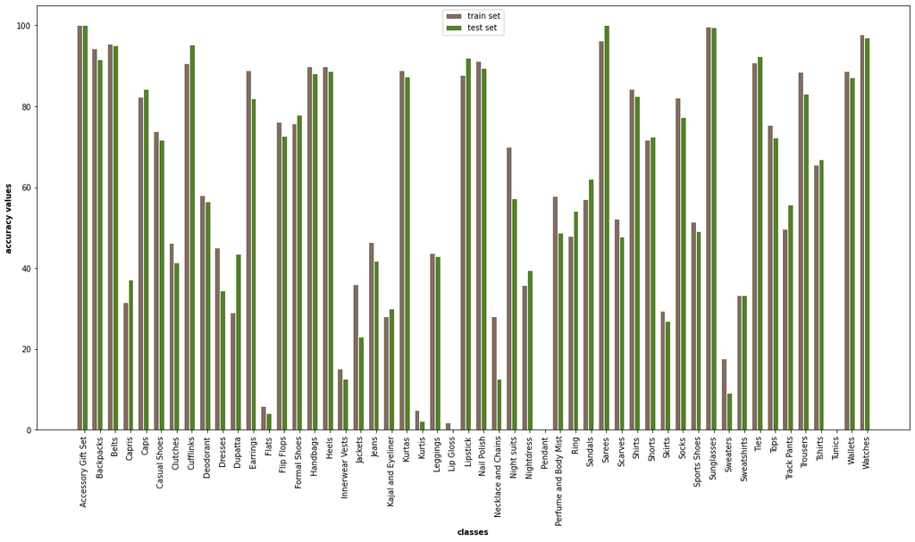

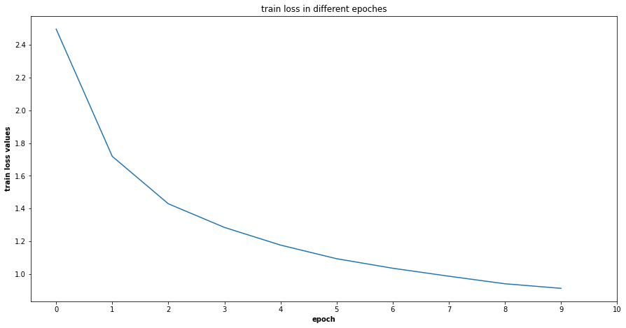

```python
check_different_batch_size(32)
```

In smaller batch sizes these are some of the things that can happen:

- lower minimum validation loss. (this is not shown in this project because the validation loss was not calculated)
- more time it takes to train per epoch. (because of the overhead of the changing between batches along with the fact that if the batch size is too small parallisation is not possible since it starts to look like sequential iterations.)
- less epochs to converge to the minimum validation loss. this can cause less total time to converge to a minimum cost.
- smaller batch sizes will generalize better because smaller batch sizes converge to flatter minimizers.
- the final weights are farther away from the initial weights in smaller batch sizes than in larger ones. This can mean elimination of effect of poor initial weights.
- each batch is a “noisy” representation of the entire dataset and seeing many batches, will cause a sort of “tug-and-pull” dynamic. This dynamic prevents the neural network from overfitting on the training set.

In this part we can see that time of each epoch has increased significantly and the the accuracy has also increased significantly which matches out initial belief.

```
Batch Size =  128
epoch 1, train_loss: 3.133, time elapsed: 22.142441 seconds
epoch 2, train_loss: 2.327, time elapsed: 22.270854 seconds
epoch 3, train_loss: 1.988, time elapsed: 22.476763 seconds
epoch 4, train_loss: 1.747, time elapsed: 22.422751 seconds
epoch 5, train_loss: 1.613, time elapsed: 22.67146 seconds
epoch 6, train_loss: 1.461, time elapsed: 22.624754 seconds
epoch 7, train_loss: 1.370, time elapsed: 22.633328 seconds
epoch 8, train_loss: 1.311, time elapsed: 22.326821 seconds
epoch 9, train_loss: 1.237, time elapsed: 22.433852 seconds
epoch 10, train_loss: 1.205, time elapsed: 22.30705 seconds
total training time: 3.739 minutes

Accuracy:
Test:  56.88590604026846
Train:  56.72673579650324
```

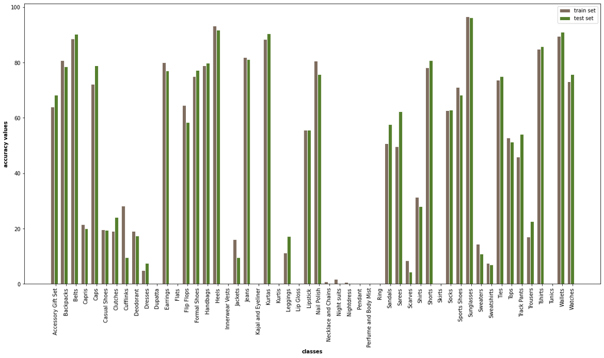

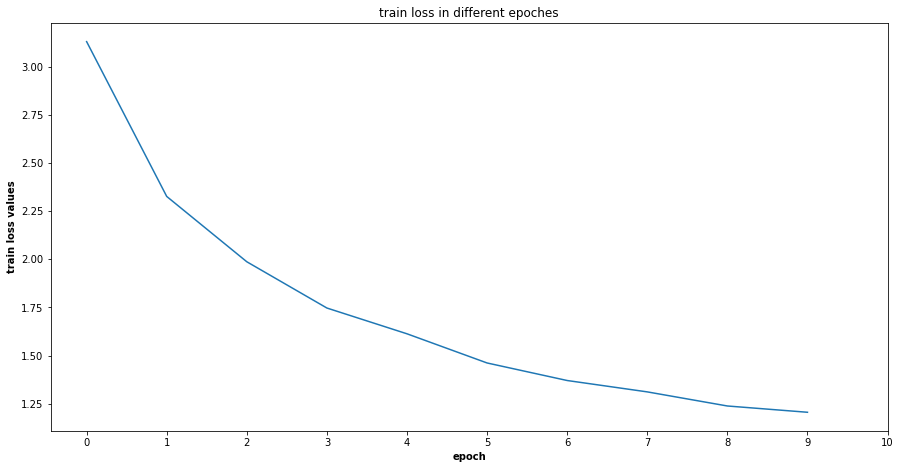

```python
check_different_batch_size(128)
```

In larger batch sizes these are some of the things that can happen:

- higher minimum validation loss. (this is not shown in this project because the validation loss was not calculated)
- less time it takes to train per epoch. (because of the lower overhead associated with loading a smaller number of large batches, as opposed to many small batches sequentially.)
- more epochs to converge to the minimum validation loss. this can cause more total time to converge to a minimum cost.
- too large of a batch size will result in poor generalization because large batch sizes converge to sharp minimizers.
- the final weights are closer to the initial weights in larger batch sizes than in smaller ones.
- is more likely to converge to the global minima.
- is more prone to overfitting to the train data.

In this part we can see that time of each epoch has dropped significantly but the accuracy is not as good as batch size = 64. This maybe because with larger batch sizes it takes more epoches to converge.

## **7-b**: Increase or Decrease in Learning Rate for Larger Batch Sizes?

Batch size = 128, Increasing and Decreasing the Learning Rate

```
Batch Size =  128
epoch 1, train_loss: 3.281, time elapsed: 22.103815 seconds
epoch 2, train_loss: 2.624, time elapsed: 22.019188 seconds
epoch 3, train_loss: 2.273, time elapsed: 22.476613 seconds
epoch 4, train_loss: 2.003, time elapsed: 22.329724 seconds
epoch 5, train_loss: 1.769, time elapsed: 22.508308 seconds
epoch 6, train_loss: 1.613, time elapsed: 22.09522 seconds
epoch 7, train_loss: 1.520, time elapsed: 22.07323 seconds
epoch 8, train_loss: 1.441, time elapsed: 22.168703 seconds
epoch 9, train_loss: 1.323, time elapsed: 22.106504 seconds
epoch 10, train_loss: 1.259, time elapsed: 22.120734 seconds
total training time: 3.700 minutes

Accuracy:
Test:  61.11409395973154
Train:  61.50541964495453
```

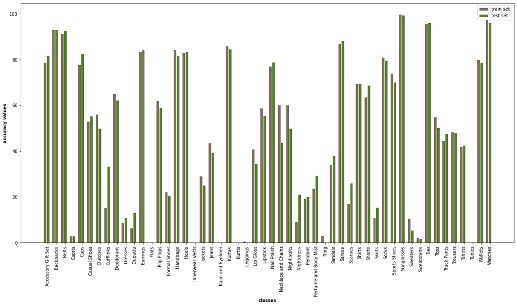

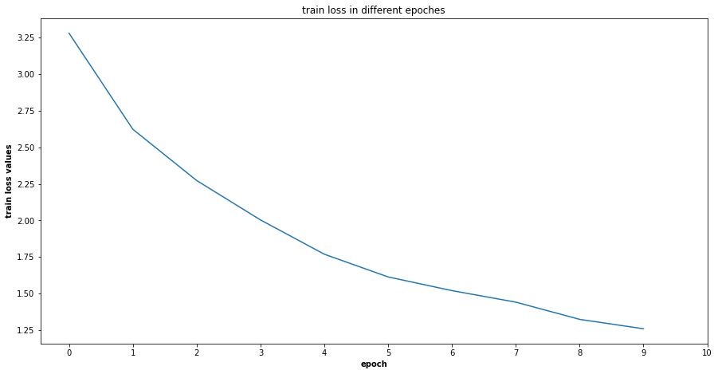

```python
check_different_batch_size(128, 0.12)
```

```
Batch Size =  128
epoch 1, train_loss: 3.581, time elapsed: 22.202932 seconds
epoch 2, train_loss: 3.304, time elapsed: 22.319729 seconds
epoch 3, train_loss: 2.897, time elapsed: 22.446021 seconds
epoch 4, train_loss: 2.679, time elapsed: 22.586425 seconds
epoch 5, train_loss: 2.470, time elapsed: 22.578153 seconds
epoch 6, train_loss: 2.297, time elapsed: 22.619393 seconds
epoch 7, train_loss: 2.119, time elapsed: 22.42041 seconds
epoch 8, train_loss: 1.960, time elapsed: 22.474582 seconds
epoch 9, train_loss: 1.831, time elapsed: 22.319345 seconds
epoch 10, train_loss: 1.749, time elapsed: 22.474367 seconds
total training time: 3.741 minutes

Accuracy:
Test:  49.006711409395976
Train:  48.4345112252089
```

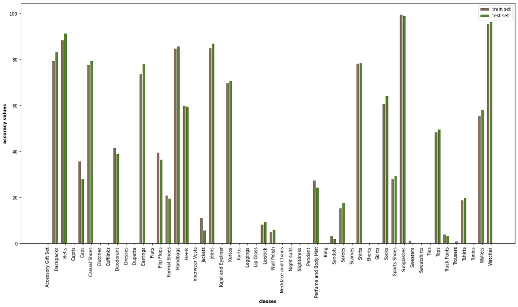

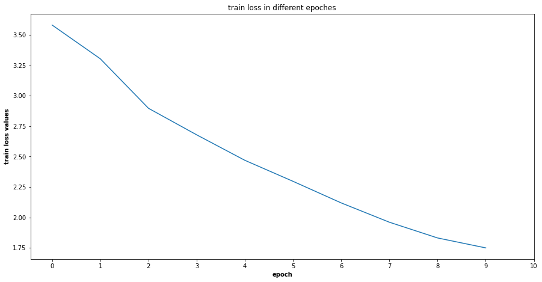

```python
check_different_batch_size(128, 0.008)
```

With larger batch sizes larger learning rates work better than smaller learning rates as is observable in the above that with a high learning rate (0.12) the accuracy is significantly better than with a smaller learning rate (0.008). The reason behind that is since the batch size is larger when changing the weights the change is representing a larger number of data which is less likely to be noise therefore if the learning rate is greater when the batch size is big the model is more likely to have good accuracy.

## **PART 8**: Observing the Effects of Momentum on the Model

## **8-a :** What is momentum and what are its pros and cons:

Momentum can be in a way thought of as a non-static learning rate.

Momentum is a method that helps accelerate SGD in the relevant direction and dampens oscillations around the local optimum. It does this by adding a fraction γ of the update vector of the past time step to the current update vector :

vt = γvt−1+η∇θJ(θ)

θ = θ−vt

The momentum term increases for dimensions whose gradients point in the same directions and reduces updates for dimensions whose gradients change directions. As a result, we gain faster convergence and reduced oscillation. In Stochastic Gradient Descent since the exact derivate of loss function is not being calculated because the loss function on a batch is calculated therefore the weights might not always be on the path to the optimal direction, because our derivatives are ‘noisy’. So, using momentum can provide a better estimate which is closer to the actual derivate than the noisy calculations.

When using momentum too small values can make the weights fluctuate and when using too large of a value the weights may have a smooth transition but the weights might shift away from the correct values.

## **8-b**:

In this part momentum values of 0.5, 0.9, 0.98 were tested for our model.

```python
def check_different_momentums(momentum_, learning_rate_=opt_lr):
  print('Momentum = ', momentum_)
  model_8 = Model(len(classes))
  model_8 = model_8.to(device)
  optimizer_8 = torch.optim.SGD(model_8.parameters(), lr=learning_rate_, momentum=momentum_)
  average_losses_8 = fit(model_8, train_loader_4, device, criterion, optimizer_8, epoch_num)

  test_acc = test_model_accuracy(model_8, test_loader_4)
  train_acc = test_model_accuracy(model_8, train_loader_4)

  print('\nAccuracy:\nTest: ', test_acc, '\nTrain: ', train_acc)
  train_cm_8 = confusion_matrix(model_8, train_loader_4, len(classes))
  test_cm_8 = confusion_matrix(model_8, test_loader_4, len(classes))
  train_accuracy_8 = accuracy_for_each_class(train_cm_8)
  test_accuracy_8 = accuracy_for_each_class(test_cm_8)


  plot_bar_chart(train_accuracy_8, test_accuracy_8)
  plot_avarage_loss(average_losses_8)
```

```
Momentum =  0.5
epoch 1, train_loss: 2.620, time elapsed: 35.947924 seconds
epoch 2, train_loss: 1.801, time elapsed: 36.113442 seconds
epoch 3, train_loss: 1.469, time elapsed: 35.838815 seconds
epoch 4, train_loss: 1.305, time elapsed: 35.983642 seconds
epoch 5, train_loss: 1.205, time elapsed: 36.030556 seconds
epoch 6, train_loss: 1.133, time elapsed: 36.060132 seconds
epoch 7, train_loss: 1.065, time elapsed: 35.802628 seconds
epoch 8, train_loss: 1.017, time elapsed: 35.847598 seconds
epoch 9, train_loss: 0.965, time elapsed: 35.786346 seconds
epoch 10, train_loss: 0.927, time elapsed: 35.858439 seconds
total training time: 5.988 minutes

Accuracy:
Test:  68.56375838926175
Train:  69.53924628343233
```

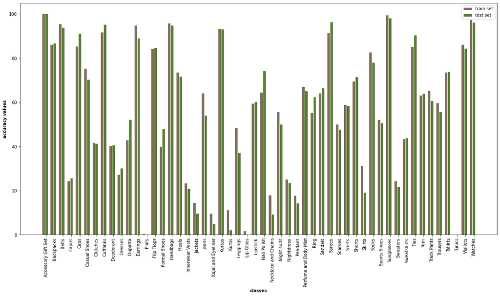

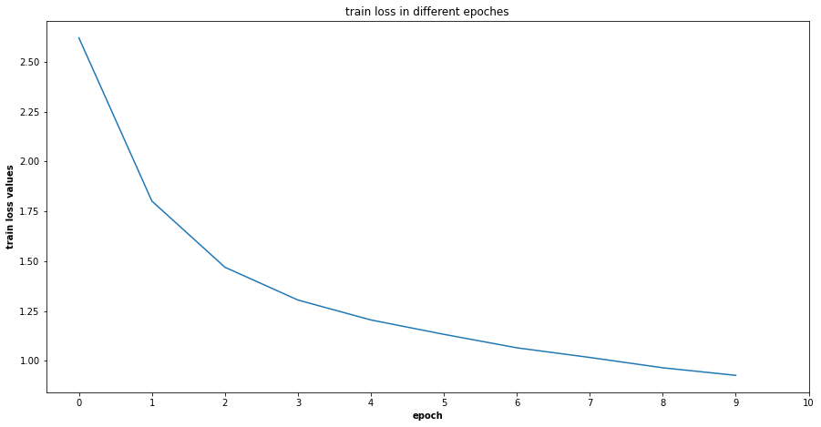

```python
check_different_momentums(0.5)
```

```
Momentum =  0.9
epoch 1, train_loss: 2.688, time elapsed: 35.785659 seconds
epoch 2, train_loss: 2.195, time elapsed: 35.637463 seconds
epoch 3, train_loss: 1.941, time elapsed: 35.457615 seconds
epoch 4, train_loss: 1.845, time elapsed: 35.435632 seconds
epoch 5, train_loss: 1.742, time elapsed: 35.326574 seconds
epoch 6, train_loss: 1.796, time elapsed: 35.424501 seconds
epoch 7, train_loss: 1.802, time elapsed: 35.589523 seconds
epoch 8, train_loss: 1.713, time elapsed: 35.762172 seconds
epoch 9, train_loss: 1.691, time elapsed: 35.438398 seconds
epoch 10, train_loss: 1.746, time elapsed: 35.367709 seconds
total training time: 5.920 minutes

Accuracy:
Test:  39.557046979865774
Train:  39.803349105674684
```

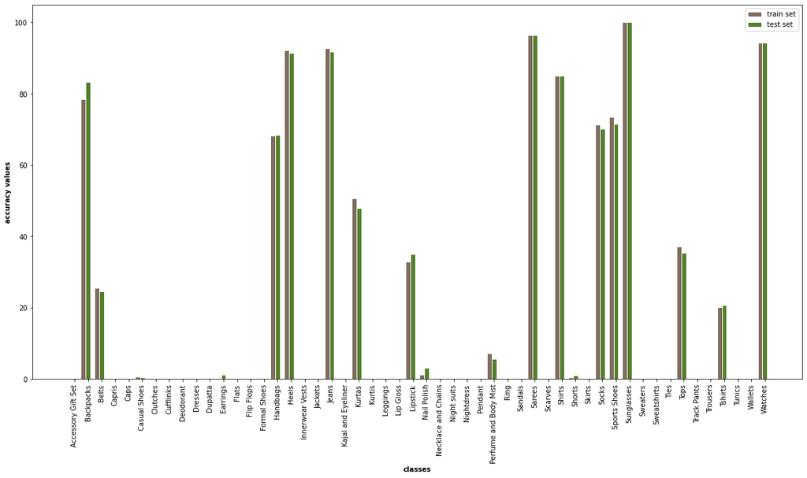

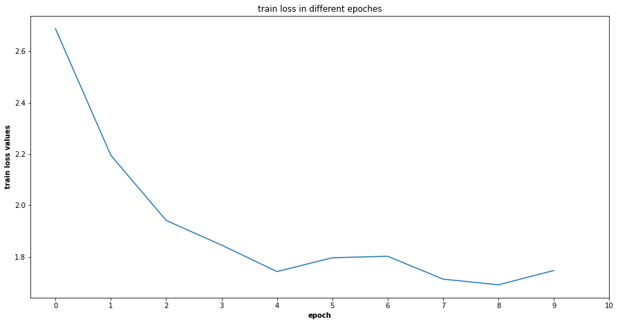

```python
check_different_momentums(0.9)
```

```
Momentum =  0.98
epoch 1, train_loss: nan, time elapsed: 35.32937 seconds
epoch 2, train_loss: nan, time elapsed: 35.407543 seconds
epoch 3, train_loss: nan, time elapsed: 35.423289 seconds
epoch 4, train_loss: nan, time elapsed: 35.714733 seconds
epoch 5, train_loss: nan, time elapsed: 35.616147 seconds
epoch 6, train_loss: nan, time elapsed: 35.341335 seconds
epoch 7, train_loss: nan, time elapsed: 35.276801 seconds
epoch 8, train_loss: nan, time elapsed: 35.339525 seconds
epoch 9, train_loss: nan, time elapsed: 35.309455 seconds
epoch 10, train_loss: nan, time elapsed: 35.446689 seconds
total training time: 5.903 minutes

Accuracy:
Test:  0.2953020134228188
Train:  0.29866774052820566
```

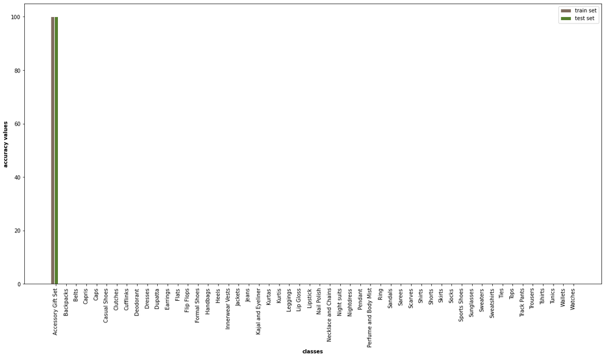

[figure not shown]

```python
 check_different_momentums(0.98)
```

```python
opt_momentum = 0.5
```

It is observable that for the 0.5 momentum value the model is working much better than without momentum, however for 0.9 momentum value the model is not doing a good job which might be because the model is missing the local optima. This is seen in the graph that after epoch 4 the loss is oscillating.

The intresting thing is when momentum value is equal to 0.98. In this case the model works like the one from section 3, meaning it is not learning at all and having nan train loss values. The reason for this can be because the learning rate is a relatively large value, so the model will not be able to decrease the gradient values and the steps get too large and the weights start to get too big and gradient explosion happens. Since the momentum is some what creating a variable learning rate and the steps are already quite big, the momentum amplifies the effect and results in gradient explosion.

Adding momentum values has added around 7 seconds to the time per epoch.

## **8-c**: Does increase in momentum necessarily result in higher accuracy?

The answer to that is no.

As seen in the previous part, best momentum value were 0.5 and 0.9 and 0.98 did not work properly.

Too big of a momentum could make the model overshoot the local optima and start oscillating around in and not converge.

## **PART 9 : Observing the Effects of Number of Epoches on the Model**

In this part the number of epoches are increased to 20 epoch.

```python
def check_differnet_epoches(epoch_):
  print("Epoch Number: ", epoch_)
  model_9 = Model(len(classes))
  model_9 = model_9.to(device)
  optimizer_9 = torch.optim.SGD(model_9.parameters(), lr=opt_lr, momentum=opt_momentum)
  average_losses_9 = fit(model_9, train_loader_4, device, criterion, optimizer_9, epoch_)

  test_acc = test_model_accuracy(model_9, test_loader_4)
  train_acc = test_model_accuracy(model_9, train_loader_4)

  print('\nAccuracy:\nTest: ', test_acc, '\nTrain: ', train_acc)
  train_cm_9 = confusion_matrix(model_9, train_loader_4, len(classes))
  test_cm_9 = confusion_matrix(model_9, test_loader_4, len(classes))
  train_accuracy_9 = accuracy_for_each_class(train_cm_9)
  test_accuracy_9 = accuracy_for_each_class(test_cm_9)


  plot_bar_chart(train_accuracy_9, test_accuracy_9)
  plot_avarage_loss(average_losses_9)
```

```
Epoch Number:  20
epoch 1, train_loss: 2.508, time elapsed: 36.129617 seconds
epoch 2, train_loss: 1.724, time elapsed: 36.193345 seconds
epoch 3, train_loss: 1.418, time elapsed: 35.894622 seconds
epoch 4, train_loss: 1.286, time elapsed: 35.940793 seconds
epoch 5, train_loss: 1.172, time elapsed: 35.85136 seconds
epoch 6, train_loss: 1.101, time elapsed: 35.917983 seconds
epoch 7, train_loss: 1.046, time elapsed: 35.81776 seconds
epoch 8, train_loss: 0.995, time elapsed: 36.132111 seconds
epoch 9, train_loss: 0.933, time elapsed: 36.063999 seconds
epoch 10, train_loss: 0.907, time elapsed: 35.76552 seconds
epoch 11, train_loss: 0.867, time elapsed: 35.735274 seconds
epoch 12, train_loss: 0.841, time elapsed: 35.689911 seconds
epoch 13, train_loss: 0.812, time elapsed: 35.767521 seconds
epoch 14, train_loss: 0.790, time elapsed: 35.896663 seconds
epoch 15, train_loss: 0.781, time elapsed: 35.974118 seconds
epoch 16, train_loss: 0.747, time elapsed: 36.098523 seconds
epoch 17, train_loss: 0.722, time elapsed: 35.730684 seconds
epoch 18, train_loss: 0.713, time elapsed: 35.86402 seconds
epoch 19, train_loss: 0.695, time elapsed: 35.749649 seconds
epoch 20, train_loss: 0.677, time elapsed: 35.891537 seconds
total training time: 11.968 minutes

Accuracy:
Test:  71.6241610738255
Train:  74.66357931474211
```

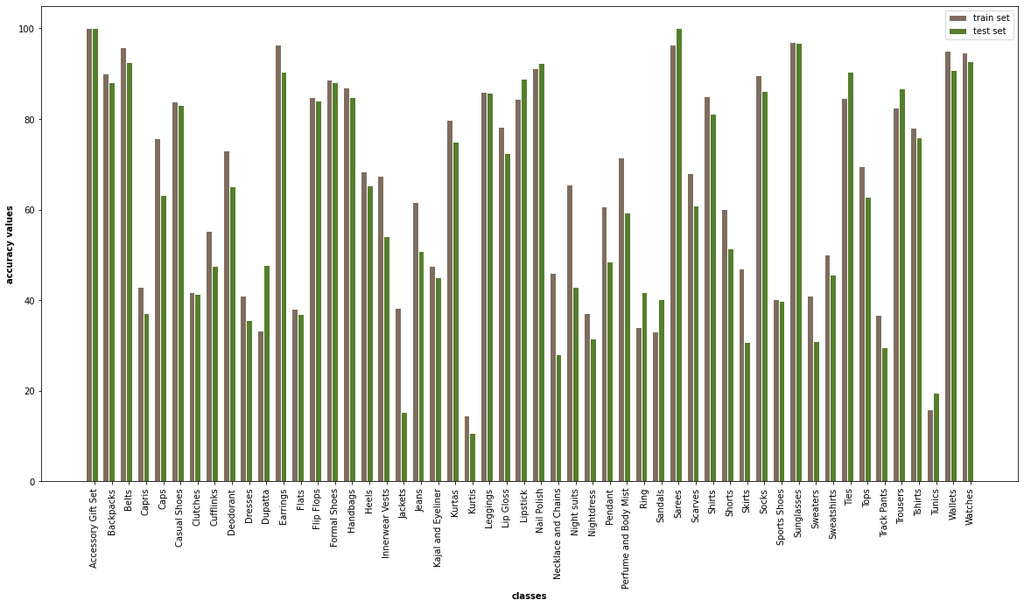

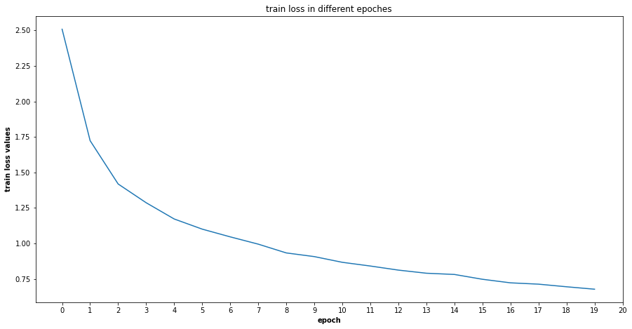

```python
check_differnet_epoches(20)
```

## **9-a**

When the epoch numbers are increased to 20 the model works better with much accuracy and lower training loss. This is because the training is continuing on for more time therefore the weights are getting closer to the right values however it has made the training time increase around two times.

## **9-b** : Why more than one epoch is needed?

Stochastic Gradient Descent is an iterative learning algorithm that uses a training dataset to update a model. The number of epochs is a hyperparameter of gradient descent that controls the number of times the whole data is being forwarded through the network. Since SGD is an iterative learning algorithm more than one epochs are needed to train the model correctly.

## **9-b : Is increase in the number of epochs always good?**

Increase in the number of epoches does not always result in better accuracy on the test set because then the model may start to overfit to the training set. However the epoch value should be as large as possible as long as the train loss is still decreasing and training should stop when the training loss curve almost flats out.

## **PART 10 : Observing the Effect of Activation Functions on the Model**

Read this [link](https://towardsdatascience.com/complete-guide-of-activation-functions-34076e95d044) for more information on this subject.

Until this part the activation function used for the model was ReLU. In this part Leaky_ReLU and Tanh are used and effects of them on the training is observed:

#### **ReLU:**

ReLU as mentioned before works like this: `x if x > 0 else 0`

Advantages of ReLU:

- ReLU has a very cheap to computation cost.
- It should converge faster than sigmoid or tanh function (but here we observe that tanh actually has decreased the training loss with a faster rate)
- Does not have the vanishing gradients problem.

Disadvantages of ReLU:

- Since all negative values will turn into zero if once a neuron gets negative it is unlikely that it will recover. This is called “dying ReLU” problem.
- ReLU can get prone to exploding gradients with large input value of large learning rates which we observed happened in different ocasions.

#### **Leaky_ReLU:**

Leacky_ReLU is a varient of ReLU and what it does is that in an attempt ot solve the dying ReLU problem it generates very small negative values instead of zero when the x is negative.

When using Leaky_ReLU instead of ReLU itself the model works just a little better but they have quite similar results.

#### **Tanh:**

The tanh function applies the following on the output of the node:

`(2/1+exp(-2x)) - 1`. This activation function is a non linear one.

- It is nonlinear in nature, so stacking of the layers is possible.
- It is bound in the range of [-1, 1]
- It can have the vanishing gradient problem.
- It works better than sigmoid function because the negative inputs will be mapped strongly negative and the zero inputs will be mapped near zero in the tanh graph.

Some points to keep in mind are:

- The sigmoid and tanh activation functions cannot be used in networks with many layers due to the vanishing gradient problem.
- When learning rate is large ReLU should be used with caution.

In this part, the tanh activation function worked better than ReLU and Leaky_ReLU.

```python
def check_different_activation(activation_func):
  print("Activation Function: ", activation_func)
  model_10 = Model(len(classes), activation_func)
  model_10 = model_10.to(device)
  optimizer_10 = torch.optim.SGD(model_10.parameters(), lr=opt_lr, momentum=opt_momentum)
  average_losses_10 = fit(model_10, train_loader_4, device, criterion, optimizer_10, epoch_num)

  test_acc = test_model_accuracy(model_10, test_loader_4)
  train_acc = test_model_accuracy(model_10, train_loader_4)

  print('\nAccuracy:\nTest: ', test_acc, '\nTrain: ', train_acc)
  train_cm_10 = confusion_matrix(model_10, train_loader_4, len(classes))
  test_cm_10 = confusion_matrix(model_10, test_loader_4, len(classes))
  train_accuracy_10 = accuracy_for_each_class(train_cm_10)
  test_accuracy_10 = accuracy_for_each_class(test_cm_10)


  plot_bar_chart(train_accuracy_10, test_accuracy_10)
  plot_avarage_loss(average_losses_10)
```

```
Activation Function:  <function tanh at 0x7efc3829e620>
```

```
epoch 1, train_loss: 2.035, time elapsed: 35.930721 seconds
epoch 2, train_loss: 1.379, time elapsed: 36.118122 seconds
epoch 3, train_loss: 1.225, time elapsed: 36.061676 seconds
epoch 4, train_loss: 1.114, time elapsed: 36.123813 seconds
epoch 5, train_loss: 1.034, time elapsed: 36.021214 seconds
epoch 6, train_loss: 0.977, time elapsed: 36.349254 seconds
epoch 7, train_loss: 0.934, time elapsed: 36.384986 seconds
epoch 8, train_loss: 0.893, time elapsed: 36.20817 seconds
epoch 9, train_loss: 0.847, time elapsed: 36.039017 seconds
epoch 10, train_loss: 0.814, time elapsed: 36.181534 seconds
total training time: 6.024 minutes

Accuracy:
Test:  75.26174496644295
Train:  76.87170710426524
```

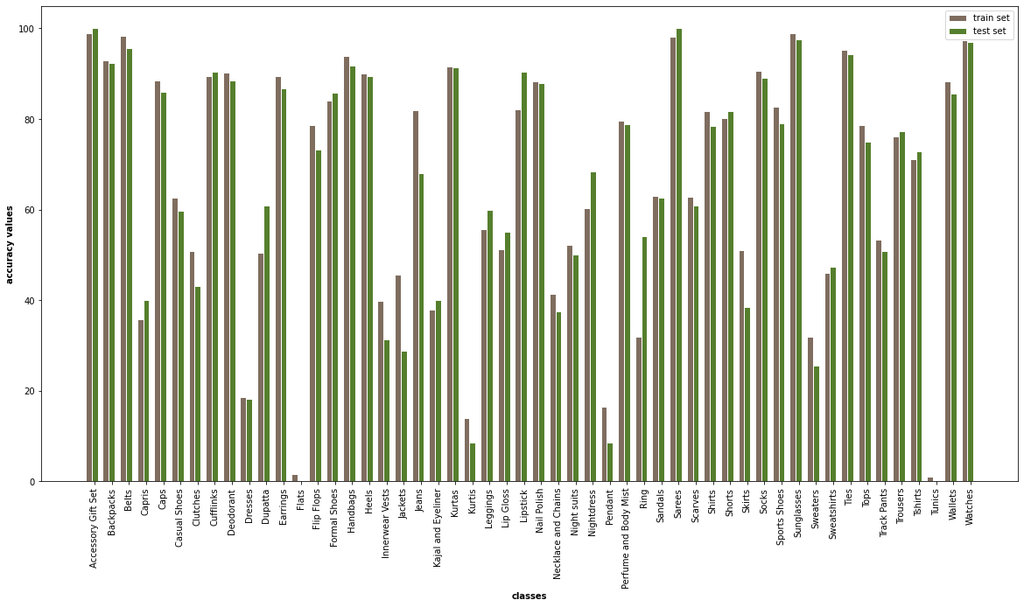

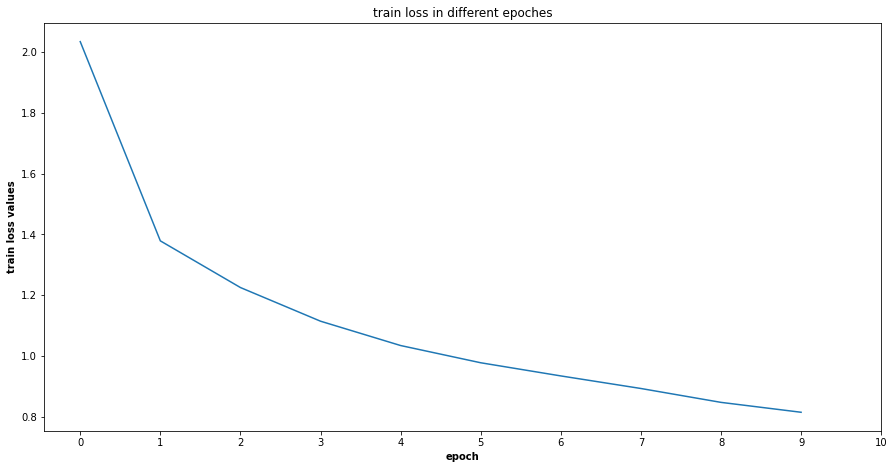

```python
check_different_activation(F.tanh)
```

```
Activation Function:  <function leaky_relu at 0x7efc3829cf28>
epoch 1, train_loss: 2.721, time elapsed: 36.169806 seconds
epoch 2, train_loss: 1.833, time elapsed: 36.362449 seconds
epoch 3, train_loss: 1.562, time elapsed: 36.203063 seconds
epoch 4, train_loss: 1.355, time elapsed: 36.279946 seconds
epoch 5, train_loss: 1.225, time elapsed: 36.057643 seconds
epoch 6, train_loss: 1.139, time elapsed: 36.127746 seconds
epoch 7, train_loss: 1.062, time elapsed: 36.046996 seconds
epoch 8, train_loss: 1.019, time elapsed: 36.142359 seconds
epoch 9, train_loss: 0.974, time elapsed: 36.29968 seconds
epoch 10, train_loss: 0.921, time elapsed: 36.153005 seconds
total training time: 6.031 minutes

Accuracy:
Test:  69.14093959731544
Train:  69.87147219705359
```

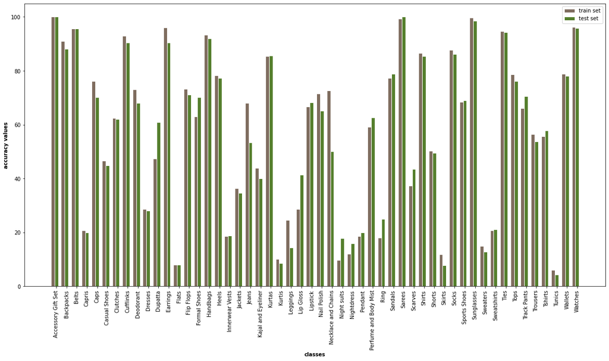

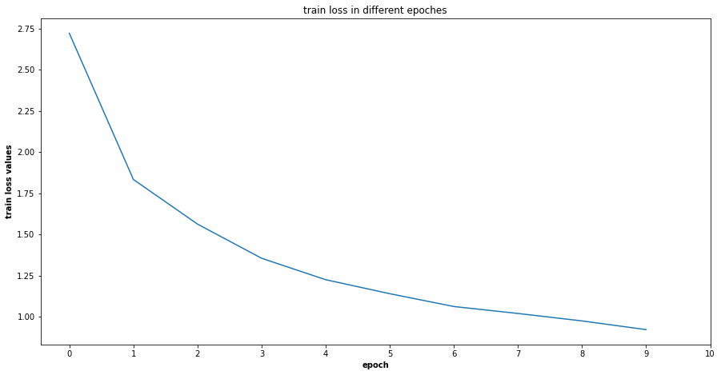

```python
check_different_activation(F.leaky_relu)
```

## **PART 11 : Observing the Effects of Regularization**

## **11-a**: How does adding regulizer term in the loss function help with overfitting?

Minimizing the training error is a reasonable thing to do, but it’s possible that the model becomes overfit to the train data.

Regularization means modifying a learning algorithm to result in simpler prediction rules thus avoiding overfitting. Most commonly, regularization refers to modifying the loss function to penalize certain values of the weights you are learning specifically, penalize weights that are large.

How the penilization works is something like this:

#### **L(w) + λ R(w)**

L(w) is the loss function that's being used.

R(w) is called the regularization term or regularizer or penalty.

λ is the hyperparameter that adjusts the tradeoff between having low training loss and having low weights.

Regularization helps the computational problem because it can prevent gradient explosion since the effects of large weight vector becomes more noticable than the gain in loss function.

There are differnet regularization terms such as L1, L2, etc.

When R(w) = ||w||^2 It is called L2 regularization.

When R(w) = ||w|| It is called L1 regularizarion.

The L2 regularization is used by default in the SGD optimizer.

## **11-b**: weight_decay term in optimizer function?

As stated before the regularization term by default in SGD optimizer is L2 and the weight_decay parameter is the λ value. Adding this parameter to the optimizer function means adding the penilizing term therefore adding the regularization.

## **11-c** : Setting weight_decay equal to 0.1

In this part model was trained with weight)decay equal to 0.1.

```python
def set_regulizer(weight_decay_):
  print("Weight Decay Value: ", weight_decay_)
  model_11 = Model(len(classes))
  model_11 = model_11.to(device)
  optimizer_11 = torch.optim.SGD(model_11.parameters(), lr=opt_lr, momentum=opt_momentum, weight_decay=weight_decay_)
  average_losses_11 = fit(model_11, train_loader_4, device, criterion, optimizer_11, epoch_num)

  test_acc = test_model_accuracy(model_11, test_loader_4)
  train_acc = test_model_accuracy(model_11, train_loader_4)

  print('\nAccuracy:\nTest: ', test_acc, '\nTrain: ', train_acc)
  train_cm_11 = confusion_matrix(model_11, train_loader_4, len(classes))
  test_cm_11 = confusion_matrix(model_11, test_loader_4, len(classes))
  train_accuracy_11 = accuracy_for_each_class(train_cm_11)
  test_accuracy_11 = accuracy_for_each_class(test_cm_11)


  plot_bar_chart(train_accuracy_11, test_accuracy_11)
  plot_avarage_loss(average_losses_11)
```

```
Weight Decay Value:  0.1
epoch 1, train_loss: 3.452, time elapsed: 40.192539 seconds
epoch 2, train_loss: 3.378, time elapsed: 40.232703 seconds
epoch 3, train_loss: 3.377, time elapsed: 40.181448 seconds
epoch 4, train_loss: 3.378, time elapsed: 40.227915 seconds
epoch 5, train_loss: 3.377, time elapsed: 40.482474 seconds
epoch 6, train_loss: 3.380, time elapsed: 40.446446 seconds
epoch 7, train_loss: 3.379, time elapsed: 40.029378 seconds
epoch 8, train_loss: 3.372, time elapsed: 40.184671 seconds
epoch 9, train_loss: 3.382, time elapsed: 40.039479 seconds
epoch 10, train_loss: 3.372, time elapsed: 40.144551 seconds
total training time: 6.703 minutes

Accuracy:
Test:  9.48993288590604
Train:  9.483539716097855
```

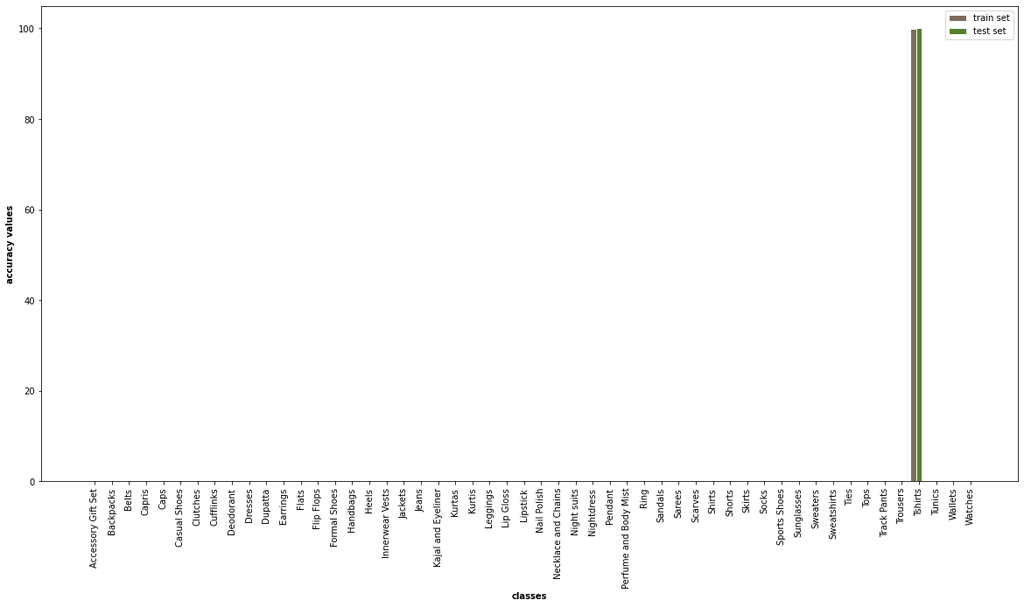

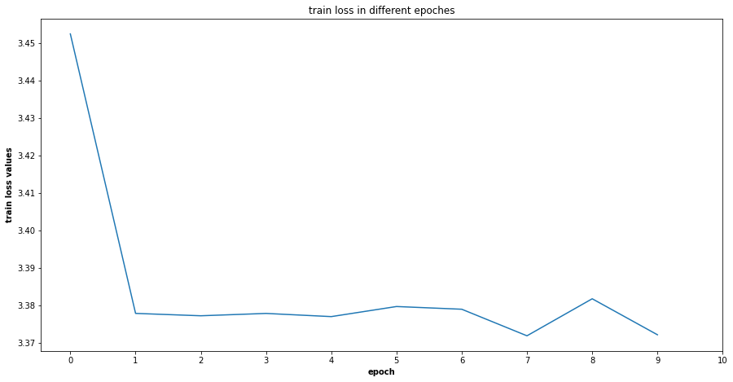

```python
set_regulizer(0.1)
```

With weight_decay added the accuracy has dropped significantly and the training loss does not decrease much and stays around the 3.4 value. The reason for the model not training well is since the weight_decay value is large, no matter how much training goes on, the model never quite fits well enough because it keeps the weights too little.

## **11-d**: Setting weight_decay equal to 0.01

In this part model was trained with weight)decay equal to 0.01.

```
Weight Decay Value:  0.01
epoch 1, train_loss: 2.626, time elapsed: 40.330568 seconds
epoch 2, train_loss: 2.023, time elapsed: 40.376334 seconds
epoch 3, train_loss: 1.904, time elapsed: 40.116335 seconds
epoch 4, train_loss: 1.832, time elapsed: 40.184985 seconds
epoch 5, train_loss: 1.767, time elapsed: 40.277935 seconds
epoch 6, train_loss: 1.780, time elapsed: 40.288289 seconds
epoch 7, train_loss: 1.825, time elapsed: 40.516718 seconds
epoch 8, train_loss: 1.827, time elapsed: 40.411759 seconds
epoch 9, train_loss: 1.793, time elapsed: 40.112366 seconds
epoch 10, train_loss: 1.727, time elapsed: 40.195539 seconds
total training time: 6.714 minutes

Accuracy:
Test:  45.651006711409394
Train:  45.41763146414309
```

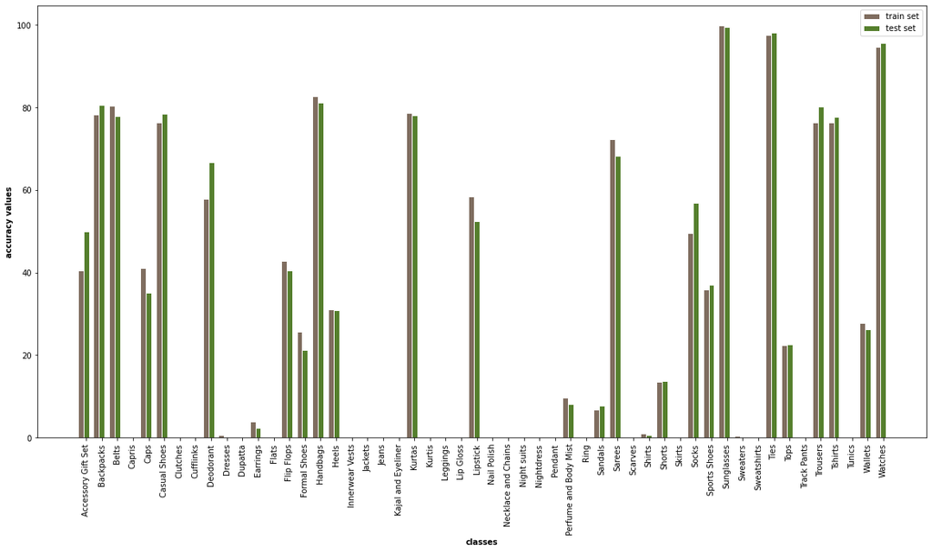

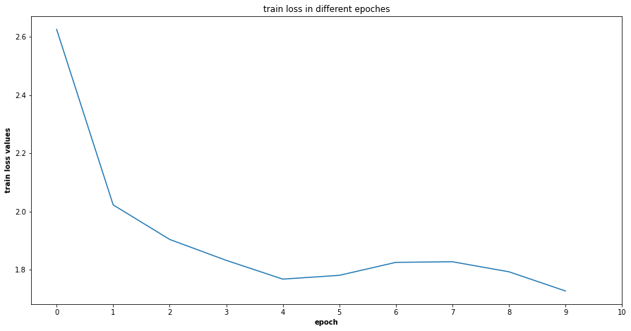

```python
set_regulizer(0.01)
```

In this part the trainig loss has decreased more and the accuracy is better than the one model with weight_decay equal to 0.1. The training time is similar to the previous part and is more than the model with weight_deay = 0.

As it is observable models with weight_decay = 0 worked better in general because the model probably was not in danger of overfitting, but actually was not probably quite near the best fit so without the regularization term it was working better.